# RR Skills (4): Dynamic Reporting

December 2 , 2014

## Information

You can forward your questions to  
Ann Greenwood (ann.greenwood at popdata.bc.ca) or Vincenza Gruppuso (vincenza at uvic.ca).  
Q&A will begin immediately after the presentation.

You can follow the presentation and review previous lectures at ialsa.github.io/COAG-colloquium-2014F/

## Overview of the Series

- Oct 14 – Intro to Reproducible Research
- Oct 21 – RR Basic Skills (1): Data Manipulation
- Nov 4 – RR Basic Skills (2): Graph Production
- Nov 18 – RR Basic Skills (3): Statistical Modeling
- Dec 2 – **RR Basic Skills (4): Dynamic Reporting**

## Previously:

[figure not shown]

```
"./Scripts/Data/dsL.R"
```

download the files to work along at [GitHub](https://github.com/IALSA/COAG-colloquium-2014F)

## Load Data

```r
# loads basic NLSY97-religiosity data as defined in COAG-Colloquium-2014F repository
dsL <- readRDS("./Data/Derived/dsL.rds")
```

```r
str(dsL)
```

```
'data.frame':   107772 obs. of  12 variables:
 $ id     : int  1 1 1 1 1 1 1 1 1 1 ...
 $ sex    : int  2 2 2 2 2 2 2 2 2 2 ...
 $ race   : int  4 4 4 4 4 4 4 4 4 4 ...
 $ bmonth : int  9 9 9 9 9 9 9 9 9 9 ...
 $ byear  : int  1981 1981 1981 1981 1981 1981 1981 1981 1981 1981 ...
 $ year   : int  2000 2001 2002 2003 2004 2005 2006 2007 2008 2009 ...
 $ attend : int  1 6 2 1 1 1 1 1 1 1 ...
 $ age    : int  19 20 21 22 23 24 25 26 27 28 ...
 $ sexF   : Ord.factor w/ 3 levels "Male"<"Female"<..: 2 2 2 2 2 2 2 2 2 2 ...
 $ raceF  : Ord.factor w/ 4 levels "Black"<"Hispanic"<..: 4 4 4 4 4 4 4 4 4 4 ...
 $ bmonthF: Ord.factor w/ 12 levels "Jan"<"Feb"<"Mar"<..: 9 9 9 9 9 9 9 9 9 9 ...
 $ attendF: Ord.factor w/ 8 levels "Never"<"Once or Twice"<..: 1 6 2 1 1 1 1 1 1 1 ...
```

## Focal outcome

```r
dsM <- dplyr::filter(dsL, id == 1) %>%
  dplyr::select(id, year, attend, attendF)
dsM
```

```
   id year attend         attendF
1   1 2000      1           Never
2   1 2001      6 About once/week
3   1 2002      2   Once or Twice
4   1 2003      1           Never
5   1 2004      1           Never
6   1 2005      1           Never
7   1 2006      1           Never
8   1 2007      1           Never
9   1 2008      1           Never
10  1 2009      1           Never
11  1 2010      1           Never
12  1 2011      1           Never
```

How often did you **attend** a worhsip service during the last year?

```
  attendLevels         attendLabels
1            8             Everyday
2            7   Several times/week
3            6      About once/week
4            5    About twice/month
5            4     About once/month
6            3 Less than once/month
7            2        Once or Twice
8            1                Never
```

## Which model is "better"?

- what criteria used?
- not used?
- preferences in fit/parsimony
- complex judgments

### Challenges:

1. Collecting results
   - *What pieces of information do we need?*
2. Organizing comparisons
   - *How do we overcome information overload?*

Model A: \({y_{it}} = {\beta _0} + {\varepsilon _{it}}\)

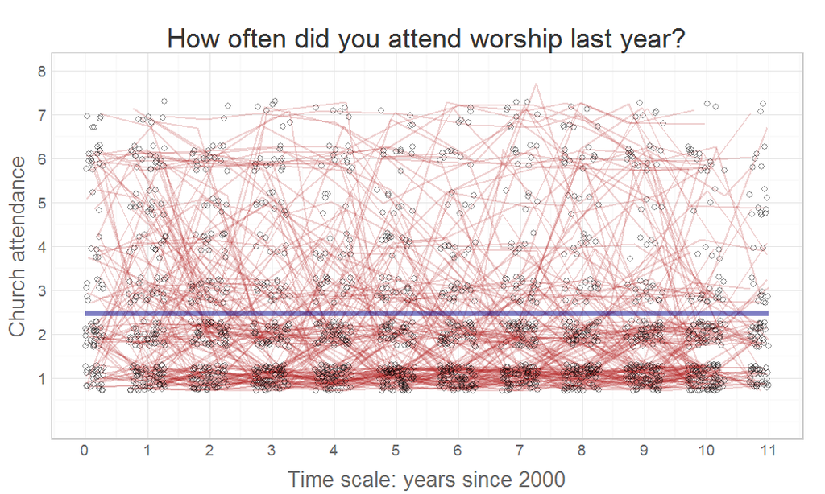

Model B: \({y_{it}} = {\beta _0} + {\beta _1}tim{e_t} + {\varepsilon _{it}}\)

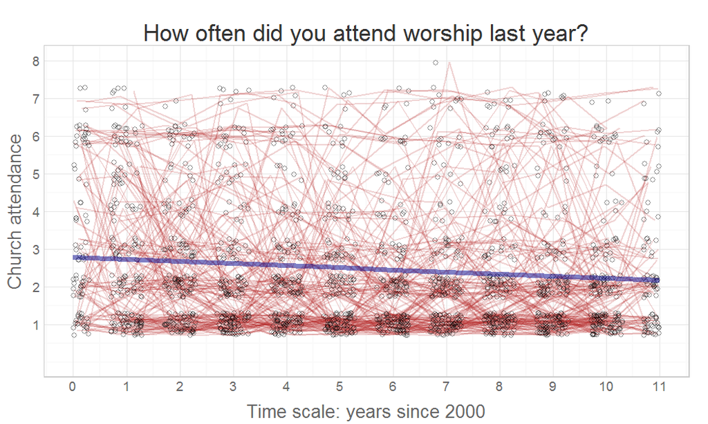

## Collecting results: post-processing

```r
print(mA)
```

```
         modelA
logLik    -3727
deviance   7453
AIC        7457
BIC        7468
df.resid   1859
N          1860
p             1
ids         155
```

```r
modelA
```

```
Generalized least squares fit by REML
  Model: attend ~ 1
  Data: dsM
  Log-restricted-likelihood: -3727

Coefficients:
(Intercept)
      2.477

Degrees of freedom: 1860 total; 1859 residual
Residual standard error: 1.793
```

\({y_{it}} = {\beta _0} + {\varepsilon _{it}}\)

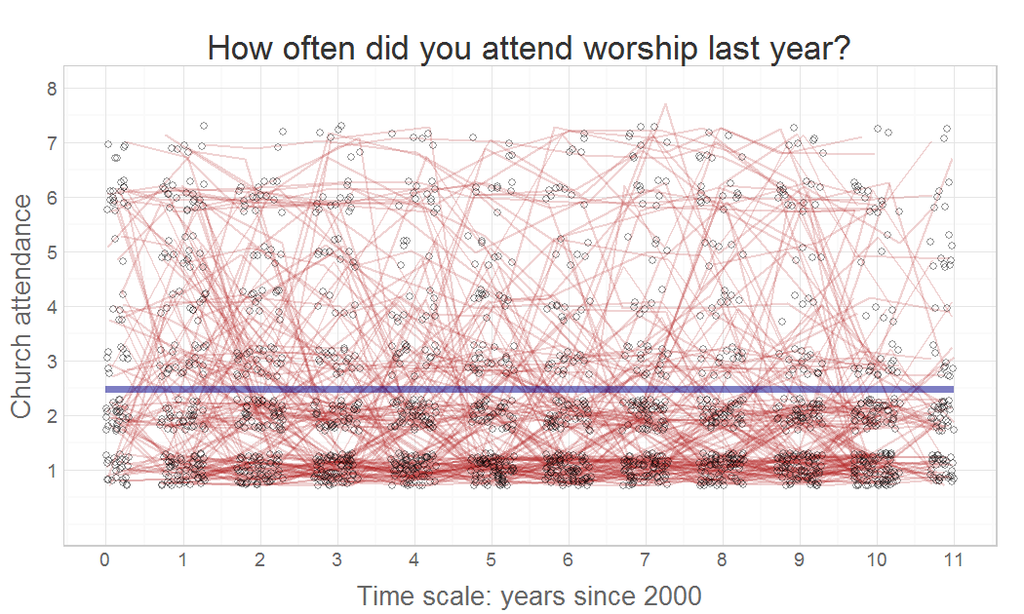

## Collecting results: post-processing

```r
print(mB)
```

```
         modelB
logLik    -3719
deviance   7438
AIC        7444
BIC        7461
df.resid   1858
N          1860
p             2
ids         155
```

```r
modelB
```

```
Generalized least squares fit by REML
  Model: attend ~ 1 + time
  Data: dsM
  Log-restricted-likelihood: -3719

Coefficients:
(Intercept)        time
     2.7882     -0.0566

Degrees of freedom: 1860 total; 1858 residual
Residual standard error: 1.782
```

\({y_{it}} = {\beta _0} + {\beta _1}tim{e_t} + {\varepsilon _{it}}\)

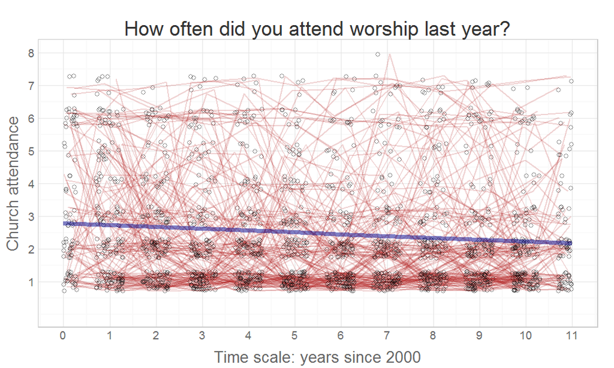

## Model manifestations

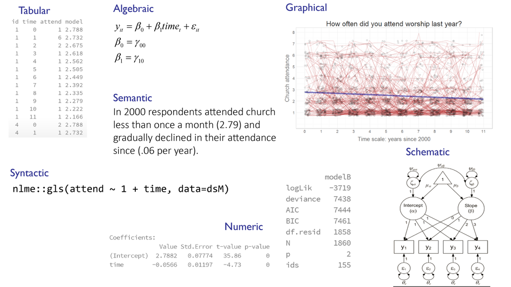

## Model manifestations

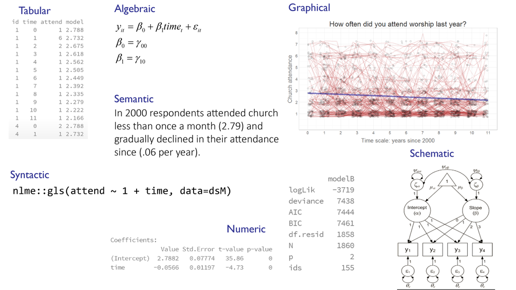

## Today

**STRATEGIC GOAL**

- Evaluate a series of models

**TACTICAL GOAL**

- Design a dynamic document for model sequencing

**TECHNICAL ASSIGNMENT**

1. choose/specify what models should constitute the sequence
2. estimate each model
3. extract and organize solutions
4. choose/create model manifestations (MM)
5. combine MMs into a report on each model
6. combine model reports into sequence report
7. customize navigation through the sequence

## Scripts involved

**model-SPECIFY.R** - contains model specifications of models as gls/lmer syntax.  
**model-ESTIMATE.R** - contains the loop that cycles through all available model specifications. Includes the following operations:  
1. Derives the dataset to be used  
2. Estimates models:  
- lme4::lmer - *if a model contains random effects*  
- nlme::gls - *if a model contains only fixed effects*  
3. Post-process model solution and save datasets:  
- `dsmInfo.rds` - *model fit and information indices*  
- `dsFERE.rds` - *fixed (FE) and random effects (RE) descriptors*  
- `dsp.rds` - *predicted values from the model*  
**model-COLLECT-SOLUTIONS.R** - combines datasets containing model solutions

## Scripts involved

**graph-FERE.R** - creates a tile graph of model solution  
**graph-PREDICT.R** - creates a line graph of predicted trajectories  
**graph-FIT** - creates a bar graph of model performance indices

**sequence.R(md)**

- produces sequence reports

another [example](http://statcanvas.net/thesis/appendix/sequences/01seqWhitesFullTj.html)

## Question? Comments?

You can forward questions to Ann Greenwood (ann.greenwood@popdata.bc.ca) or Vincenza Gruppuso (vincenza@uvic.ca) during the live Q&A. They are standing by to take your questions.